# ISLR Chapter 6 - applied

## Exercise 8

**In this exercise, we will generate simulated data, and will then use this data to perform best subset selection.**

**Use the `rnorm()` function to generate a predictor $X$ of length $n=100$, as well as a noise vector $\epsilon$ of length $n=100$.**

```r
set.seed(123)
x <- rnorm(100)
eps <- rnorm(100)
```

**Generate a response vector $Y$ of length $n=100$ according to the model**
$$Y=\beta_0+\beta_1X+\beta_2X^2+\beta_3X^3+\epsilon$$
**where $\beta_0$, $\beta_1$, $\beta_2$, and $\beta_0$ are constants of your choice.**

Letting $\beta_0=10$, $\beta_1=2$, $\beta_2=4$ and $\beta_3=3$:

```r
y <- 10 + 2*x + 4*x^2 + 3*x^3 + eps
```

**Use the `regsubsets()` function to perform best subset selection in order to choose the best model containing the predictors $X$, $X^2$, …, $X^{10}$. What is the best model obtained according to $C_p$, $BIC$, and adjusted $R^2$? Show some plots to provide evidence for your answer, and report the coefficients of the best model obtained. Note you will need to use the `data.frame()` function to create a single data set containing both $X$ and $Y$.**

```r
mydata <- data.frame(x, y)
reg.fit <- regsubsets(y ~ poly(x, 10, raw = TRUE), data = mydata, nvmax = 10)
reg.summary <- summary(reg.fit)
reg.summary
```

```
## Subset selection object
## Call: regsubsets.formula(y ~ poly(x, 10, raw = TRUE), data = mydata,
##     nvmax = 10)
## 10 Variables  (and intercept)
##                           Forced in Forced out
## poly(x, 10, raw = TRUE)1      FALSE      FALSE
## poly(x, 10, raw = TRUE)2      FALSE      FALSE
## poly(x, 10, raw = TRUE)3      FALSE      FALSE
## poly(x, 10, raw = TRUE)4      FALSE      FALSE
## poly(x, 10, raw = TRUE)5      FALSE      FALSE
## poly(x, 10, raw = TRUE)6      FALSE      FALSE
## poly(x, 10, raw = TRUE)7      FALSE      FALSE
## poly(x, 10, raw = TRUE)8      FALSE      FALSE
## poly(x, 10, raw = TRUE)9      FALSE      FALSE
## poly(x, 10, raw = TRUE)10     FALSE      FALSE
```

[output cut: 57 more lines]

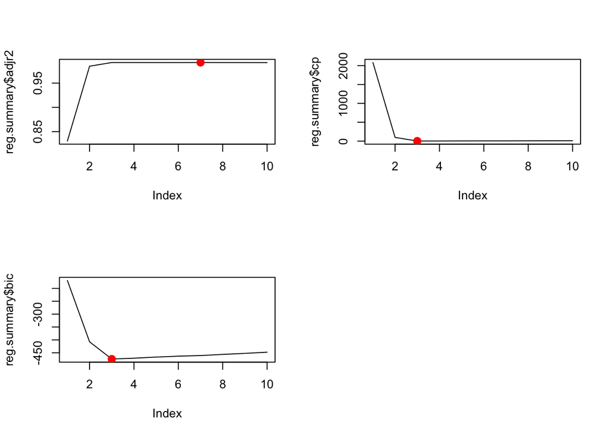

```r
par(mfrow=c(2,2))
plot(reg.summary$adjr2, type = "l")
points(which.max(reg.summary$adjr2),reg.summary$adjr2[which.max(reg.summary$adjr2)], col="red",cex=2,pch=20)
plot(reg.summary$cp, type = "l")
points(which.min(reg.summary$cp),reg.summary$cp[which.min(reg.summary$cp)], col="red",cex=2,pch=20)
plot(reg.summary$bic, type = "l")
points(which.min(reg.summary$bic),reg.summary$bic[which.min(reg.summary$bic)], col="red",cex=2,pch=20)
```

The best model using adjusted $R^2$ has 7 predictors, and for $C_P$ and $BIC$, 3 predictors.

The coefficients for each of these models are:

```r
coef(reg.fit, id = 7)
```

```
##               (Intercept)  poly(x, 10, raw = TRUE)1  poly(x, 10, raw = TRUE)2
##                 9.7931750                 1.8907484                 6.2758848
##  poly(x, 10, raw = TRUE)3  poly(x, 10, raw = TRUE)4  poly(x, 10, raw = TRUE)6
##                 3.0530514                -4.0243410                 2.2138377
##  poly(x, 10, raw = TRUE)8 poly(x, 10, raw = TRUE)10
##                -0.4870719                 0.0373538
```

```r
coef(reg.fit, id = 3)
```

```
##              (Intercept) poly(x, 10, raw = TRUE)1 poly(x, 10, raw = TRUE)2
##                 9.970394                 1.920446                 3.908457
## poly(x, 10, raw = TRUE)3
##                 3.020436
```

**Repeat (c), using forward stepwise selection and also using backwards stepwise selection. How does your answer compare to the results in (c)?**

```r
regfit.fwd <- regsubsets(y ~ poly(x, 10, raw = TRUE), data = mydata, method = "forward", nvmax = 10)
reg.summary <- summary(regfit.fwd)
reg.summary
```

```
## Subset selection object
## Call: regsubsets.formula(y ~ poly(x, 10, raw = TRUE), data = mydata,
##     method = "forward", nvmax = 10)
## 10 Variables  (and intercept)
##                           Forced in Forced out
## poly(x, 10, raw = TRUE)1      FALSE      FALSE
## poly(x, 10, raw = TRUE)2      FALSE      FALSE
## poly(x, 10, raw = TRUE)3      FALSE      FALSE
## poly(x, 10, raw = TRUE)4      FALSE      FALSE
## poly(x, 10, raw = TRUE)5      FALSE      FALSE
## poly(x, 10, raw = TRUE)6      FALSE      FALSE
## poly(x, 10, raw = TRUE)7      FALSE      FALSE
## poly(x, 10, raw = TRUE)8      FALSE      FALSE
## poly(x, 10, raw = TRUE)9      FALSE      FALSE
## poly(x, 10, raw = TRUE)10     FALSE      FALSE
```

[output cut: 57 more lines]

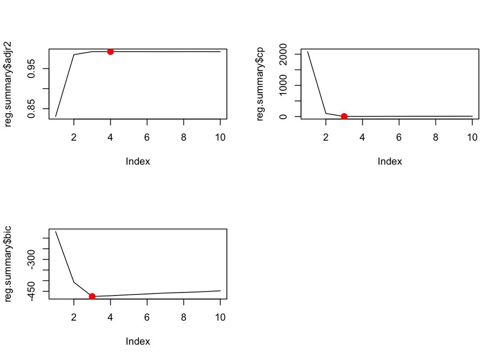

```r
par(mfrow=c(2,2))
plot(reg.summary$adjr2, type = "l")
points(which.max(reg.summary$adjr2),reg.summary$adjr2[which.max(reg.summary$adjr2)], col="red",cex=2,pch=20)
plot(reg.summary$cp, type = "l")
points(which.min(reg.summary$cp),reg.summary$cp[which.min(reg.summary$cp)], col="red",cex=2,pch=20)
plot(reg.summary$bic, type = "l")
points(which.min(reg.summary$bic),reg.summary$bic[which.min(reg.summary$bic)], col="red",cex=2,pch=20)
```

Using forward subset selection, adjusted $R^2$ picked the four variable model, and both $C_p$ and $BIC$ picked the three variable model.

```r
regfit.bwd <- regsubsets(y ~ poly(x, 10), data = mydata, method = "backward", nvmax = 10)
reg.summary <- summary(regfit.bwd)
reg.summary
```

```
## Subset selection object
## Call: regsubsets.formula(y ~ poly(x, 10), data = mydata, method = "backward",
##     nvmax = 10)
## 10 Variables  (and intercept)
##               Forced in Forced out
## poly(x, 10)1      FALSE      FALSE
## poly(x, 10)2      FALSE      FALSE
## poly(x, 10)3      FALSE      FALSE
## poly(x, 10)4      FALSE      FALSE
## poly(x, 10)5      FALSE      FALSE
## poly(x, 10)6      FALSE      FALSE
## poly(x, 10)7      FALSE      FALSE
## poly(x, 10)8      FALSE      FALSE
## poly(x, 10)9      FALSE      FALSE
## poly(x, 10)10     FALSE      FALSE
## 1 subsets of each size up to 10
## Selection Algorithm: backward
##           poly(x, 10)1 poly(x, 10)2 poly(x, 10)3 poly(x, 10)4 poly(x, 10)5
## 1  ( 1 )  "*"          " "          " "          " "          " "
## 2  ( 1 )  "*"          "*"          " "          " "          " "
## 3  ( 1 )  "*"          "*"          "*"          " "          " "
## 4  ( 1 )  "*"          "*"          "*"          " "          " "
## 5  ( 1 )  "*"          "*"          "*"          "*"          " "
## 6  ( 1 )  "*"          "*"          "*"          "*"          " "
## 7  ( 1 )  "*"          "*"          "*"          "*"          " "
## 8  ( 1 )  "*"          "*"          "*"          "*"          " "
## 9  ( 1 )  "*"          "*"          "*"          "*"          "*"
## 10  ( 1 ) "*"          "*"          "*"          "*"          "*"
##           poly(x, 10)6 poly(x, 10)7 poly(x, 10)8 poly(x, 10)9 poly(x, 10)10
## 1  ( 1 )  " "          " "          " "          " "          " "
## 2  ( 1 )  " "          " "          " "          " "          " "
## 3  ( 1 )  " "          " "          " "          " "          " "
## 4  ( 1 )  " "          " "          "*"          " "          " "
## 5  ( 1 )  " "          " "          "*"          " "          " "
## 6  ( 1 )  " "          " "          "*"          " "          "*"
## 7  ( 1 )  " "          "*"          "*"          " "          "*"
## 8  ( 1 )  "*"          "*"          "*"          " "          "*"
## 9  ( 1 )  "*"          "*"          "*"          " "          "*"
## 10  ( 1 ) "*"          "*"          "*"          "*"          "*"
```

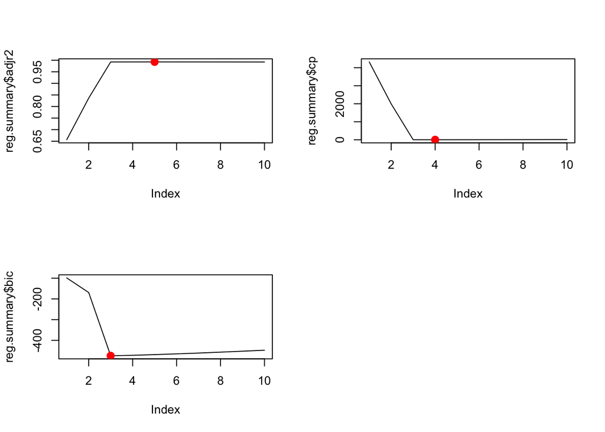

```r
par(mfrow=c(2,2))
plot(reg.summary$adjr2, type = "l")
points(which.max(reg.summary$adjr2),reg.summary$adjr2[which.max(reg.summary$adjr2)], col="red",cex=2,pch=20)
plot(reg.summary$cp, type = "l")
points(which.min(reg.summary$cp),reg.summary$cp[which.min(reg.summary$cp)], col="red",cex=2,pch=20)
plot(reg.summary$bic, type = "l")
points(which.min(reg.summary$bic),reg.summary$bic[which.min(reg.summary$bic)], col="red",cex=2,pch=20)
```

Using backward subset selection, adjusted $R^2$ picked the five variable model, $C_p$ the four variable model, and $BIC$ the three variable model.

These results are quite similar to best subset - adjusted $R^2$ appears to generally pick more complex models, and $BIC$ picked the three variable model with all three methods.

**Now fit a lasso model to the simulated data, again using $X$, $X^2$, …, $X^{10}$ as predictors. Use cross-validation to select the optimal value of $\lambda$. Create plots of the cross-validation error as a function of $\lambda$. Report the resulting coefficient estimates, and discuss the results obtained.**

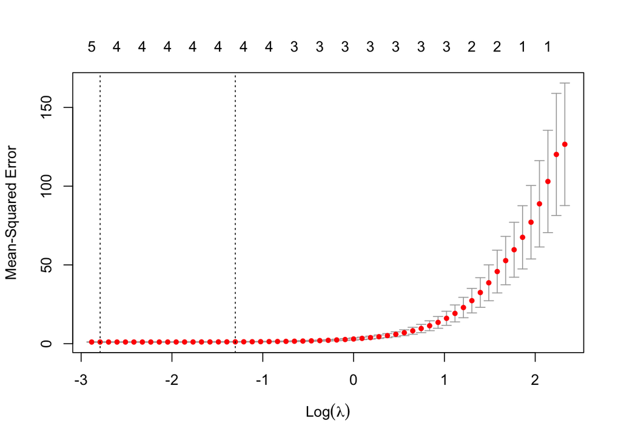

```r
set.seed(123)
data.mat <- model.matrix(y ~ poly(x, 10, raw = TRUE), data = mydata)[, -1]
lasso.mod <- cv.glmnet(data.mat, y, alpha = 1)
plot(lasso.mod)
```

```r
lasso.coef <- predict(lasso.mod, type="coefficients", s = lasso.mod$lambda.min)
lasso.coef
```

```
## 11 x 1 sparse Matrix of class "dgCMatrix"
##                                      1
## (Intercept)               1.007899e+01
## poly(x, 10, raw = TRUE)1  1.892388e+00
## poly(x, 10, raw = TRUE)2  3.667849e+00
## poly(x, 10, raw = TRUE)3  3.011078e+00
## poly(x, 10, raw = TRUE)4  4.872684e-02
## poly(x, 10, raw = TRUE)5  .
## poly(x, 10, raw = TRUE)6  6.344157e-07
## poly(x, 10, raw = TRUE)7  .
## poly(x, 10, raw = TRUE)8  .
## poly(x, 10, raw = TRUE)9  .
## poly(x, 10, raw = TRUE)10 .
```

Lasso has selected the first three terms, fitting coefficients that match the true values closely. It has also selected the fourth and sixth terms, but the coefficients for these are very small. All other terms’ coefficients have been shrunk to zero.

**Now generate a response vector $Y$ according to the model:**
$$Y = \beta_0 + \beta_7X^7 + \epsilon$$
**and perform best subset selection and the lasso. Discuss the results obtained.**

```r
y_seventh <- 10 + 3 * I(x^7) + eps
```

Performing best subsets selection:

```r
mydata <- data.frame(x, y_seventh)
reg.fit <- regsubsets(y_seventh ~ poly(x, 10, raw = TRUE), data = mydata, nvmax = 10)
reg.summary <- summary(reg.fit)
reg.summary
```

```
## Subset selection object
## Call: regsubsets.formula(y_seventh ~ poly(x, 10, raw = TRUE), data = mydata,
##     nvmax = 10)
## 10 Variables  (and intercept)
##                           Forced in Forced out
## poly(x, 10, raw = TRUE)1      FALSE      FALSE
## poly(x, 10, raw = TRUE)2      FALSE      FALSE
## poly(x, 10, raw = TRUE)3      FALSE      FALSE
## poly(x, 10, raw = TRUE)4      FALSE      FALSE
## poly(x, 10, raw = TRUE)5      FALSE      FALSE
## poly(x, 10, raw = TRUE)6      FALSE      FALSE
## poly(x, 10, raw = TRUE)7      FALSE      FALSE
## poly(x, 10, raw = TRUE)8      FALSE      FALSE
## poly(x, 10, raw = TRUE)9      FALSE      FALSE
## poly(x, 10, raw = TRUE)10     FALSE      FALSE
```

[output cut: 57 more lines]

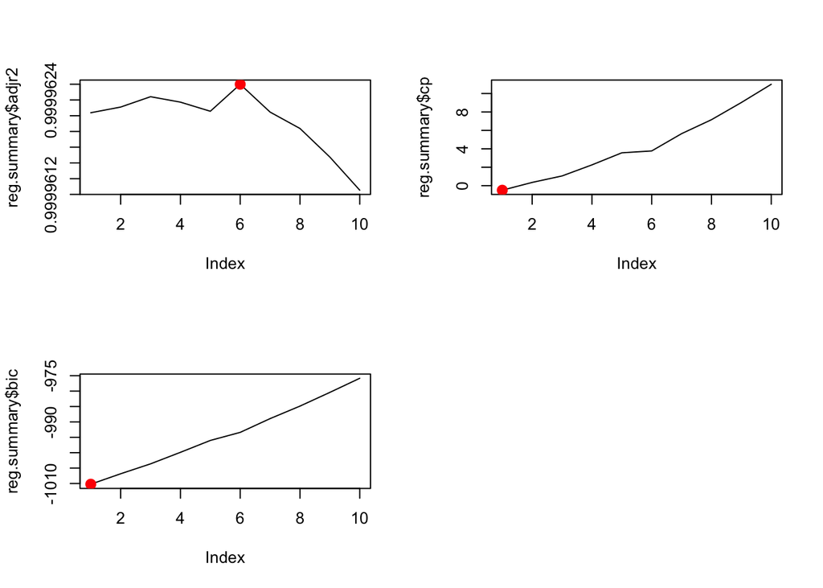

```r
par(mfrow=c(2,2))
plot(reg.summary$adjr2, type = "l")
points(which.max(reg.summary$adjr2),reg.summary$adjr2[which.max(reg.summary$adjr2)], col="red",cex=2,pch=20)
plot(reg.summary$cp, type = "l")
points(which.min(reg.summary$cp),reg.summary$cp[which.min(reg.summary$cp)], col="red",cex=2,pch=20)
plot(reg.summary$bic, type = "l")
points(which.min(reg.summary$bic),reg.summary$bic[which.min(reg.summary$bic)], col="red",cex=2,pch=20)
```

Best subset suggests a model with 1 predictor, being the seventh polynomial term, when we use $BIC$ or $C_p$ as the model assessment criterion. Adjusted $R^2$ picks a six variable model.

Now fit a lasso regression:

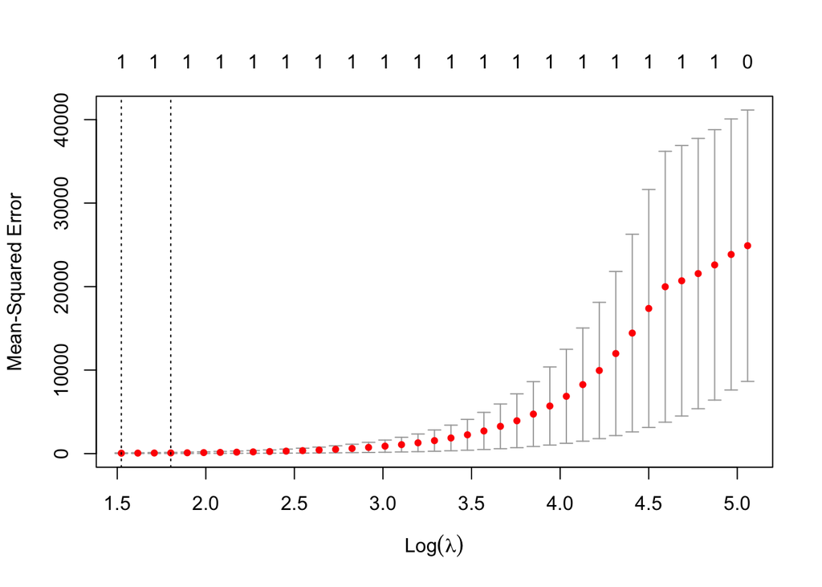

```r
set.seed(123)
data.mat <- model.matrix(y ~ poly(x, 10, raw = TRUE), data = mydata)[, -1]
lasso.mod <- cv.glmnet(data.mat, y_seventh, alpha = 1)
plot(lasso.mod)
```

```r
lasso.coef <- predict(lasso.mod, type="coefficients", s = lasso.mod$lambda.min)
lasso.coef
```

```
## 11 x 1 sparse Matrix of class "dgCMatrix"
##                                   1
## (Intercept)               10.129368
## poly(x, 10, raw = TRUE)1   .
## poly(x, 10, raw = TRUE)2   .
## poly(x, 10, raw = TRUE)3   .
## poly(x, 10, raw = TRUE)4   .
## poly(x, 10, raw = TRUE)5   .
## poly(x, 10, raw = TRUE)6   .
## poly(x, 10, raw = TRUE)7   2.912261
## poly(x, 10, raw = TRUE)8   .
## poly(x, 10, raw = TRUE)9   .
## poly(x, 10, raw = TRUE)10  .
```

The model selected by lasso regression has picked out only the seventh polynomial term, with the correct coefficient.

# Exercise 9

**In this exercise, we will predict the number of applications received using the other variables in the `College` data set.**

**Split the data set into a training set and a test set.**

```r
set.seed(123)
train_idx <- sample(nrow(College), 0.7*nrow(College), replace = FALSE)
```

**Fit a linear model using least squares on the training set, and report the test error obtained.**

```r
lm.fit <- lm(Apps ~ ., data = College, subset = train_idx)
lm.preds <- predict(lm.fit, newdata = College)
sqrt(mean((College$Apps - lm.preds)[-train_idx]^2))
```

```
## [1] 1317.134
```

**Fit a ridge regression model on the training set, with $\lambda$ chosen by cross-validation. Report the test error obtained.**

```r
xtrain <- model.matrix(Apps ~ ., data = College[train_idx,])[,-1]
xtest <- model.matrix(Apps ~ ., data = College[-train_idx,])[,-1]
ridge.fit <- cv.glmnet(xtrain, College$Apps[train_idx], alpha = 0)
ridge.pred <- predict(ridge.fit, newx = xtest, s = ridge.fit$lambda.min)
sqrt(mean((College$Apps[-train_idx] - ridge.pred)^2))
```

```
## [1] 1725.214
```

The MSE is higher than that for the initial linear model.

**Fit a lasso model on the training set, with $\lambda$ chosen by cross-validation. Report the test error obtained, along with the number of non-zero coefficient estimates.**

```r
lasso.fit <- cv.glmnet(xtrain, College$Apps[train_idx], alpha = 1)
lasso.pred <- predict(lasso.fit, newx = xtest, s = lasso.fit$lambda.min)
sqrt(mean((College$Apps[-train_idx] - lasso.pred)^2))
```

```
## [1] 1315.667
```

```r
predict(lasso.fit, s = lasso.fit$lambda.min, type = "coefficients")
```

```
## 18 x 1 sparse Matrix of class "dgCMatrix"
##                         1
## (Intercept) -463.16836151
## PrivateYes  -656.20702293
## Accept         1.21783190
## Enroll         0.08572013
## Top10perc     44.62627170
## Top25perc    -12.15289502
## F.Undergrad    0.02285926
## P.Undergrad    0.02766092
## Outstate      -0.04625746
## Room.Board     0.17470910
## Books          0.15590265
## Personal      -0.01368495
## PhD           -5.00902576
## Terminal      -4.87226972
## S.F.Ratio      .
## perc.alumni   -7.47213193
## Expend         0.07508426
## Grad.Rate      9.36204101
```

**Fit a PCR model on the training set, with $M$ chosen by cross-validation. Report the test error obtained, along with the value of $M$ selected by cross-validation.**

```r
pcr.fit <- pcr(Apps ~ ., data = College[train_idx,], scale = TRUE, validation = "CV")
summary(pcr.fit)
```

```
## Data:    X dimension: 543 17
##  Y dimension: 543 1
## Fit method: svdpc
## Number of components considered: 17
##
## VALIDATION: RMSEP
## Cross-validated using 10 random segments.
##        (Intercept)  1 comps  2 comps  3 comps  4 comps  5 comps  6 comps
## CV            3402     3361     1675     1634     1347     1299     1264
## adjCV         3402     3361     1673     1632     1325     1289     1262
##        7 comps  8 comps  9 comps  10 comps  11 comps  12 comps  13 comps
## CV        1218     1210     1163      1163      1164      1166      1165
## adjCV     1207     1208     1161      1162      1163      1164      1163
##        14 comps  15 comps  16 comps  17 comps
## CV         1166      1171      1027      1028
## adjCV      1164      1170      1024      1025
##
## TRAINING: % variance explained
##       1 comps  2 comps  3 comps  4 comps  5 comps  6 comps  7 comps  8 comps
## X      31.797    57.68    64.58     70.2    75.49    80.41    84.00    87.43
## Apps    3.037    76.20    77.49     85.1    86.15    86.83    87.92    88.01
##       9 comps  10 comps  11 comps  12 comps  13 comps  14 comps  15 comps
## X       90.62     93.05     95.12     96.96     98.04     98.89     99.42
## Apps    88.85     88.87     88.94     88.98     89.01     89.01     89.03
##       16 comps  17 comps
## X        99.83    100.00
## Apps     91.68     91.75
```

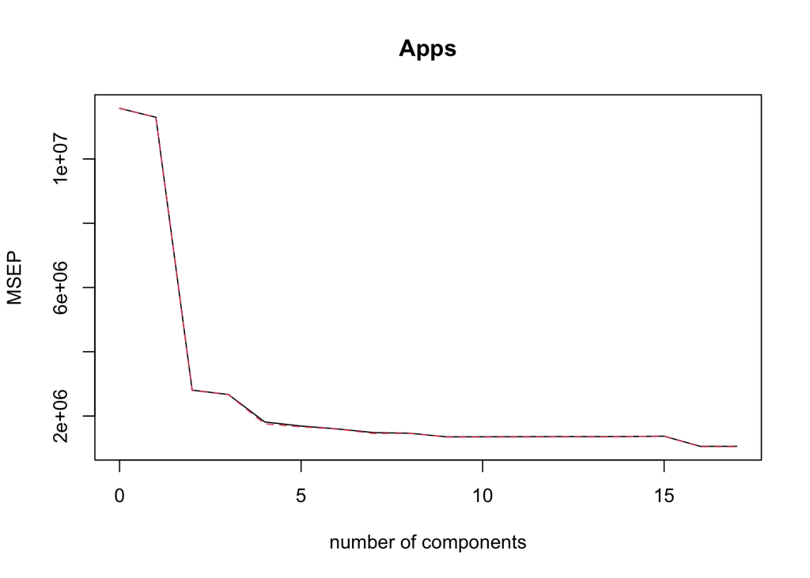

```r
validationplot(pcr.fit, val.type = "MSEP")
```

The lowest CV error occurs where 16 components are used, which is barely smaller than the number of predictors, 17.

Applying the one-standard-error rule suggests using 7 components:

```r
cv_errors <- RMSEP(pcr.fit)$val[1,1,]
one_se_rule <- cv_errors[which.min(cv_errors)] + sd(cv_errors)/sqrt(10)
names(which.max(cv_errors[cv_errors < one_se_rule]))
```

```
## [1] "7 comps"
```

Calculating the test error for 7 components:

```r
pcr.preds <- predict(pcr.fit, newdata = College[-train_idx,], ncomp = 7)
sqrt(mean((College$Apps[-train_idx] - pcr.preds)^2))
```

```
## [1] 2035.574
```

Calculating the test error for 16 components:

```r
pcr.preds <- predict(pcr.fit, newdata = College[-train_idx,], ncomp = 16)
sqrt(mean((College$Apps[-train_idx] - pcr.preds)^2))
```

```
## [1] 1361.483
```

**Fit a PLS model on the training set, with $M$ chosen by cross-validation. Report the test error obtained, along with the value of M selected by cross-validation.**

```r
pls.fit <- plsr(Apps ~ ., data = College[train_idx,], scale = TRUE, validation = "CV")
summary(pls.fit)
```

```
## Data:    X dimension: 543 17
##  Y dimension: 543 1
## Fit method: kernelpls
## Number of components considered: 17
##
## VALIDATION: RMSEP
## Cross-validated using 10 random segments.
##        (Intercept)  1 comps  2 comps  3 comps  4 comps  5 comps  6 comps
## CV            3402     1515     1253     1150     1120     1095     1052
## adjCV         3402     1512     1256     1148     1117     1090     1048
##        7 comps  8 comps  9 comps  10 comps  11 comps  12 comps  13 comps
## CV        1038     1037     1038      1038      1037      1038      1038
## adjCV     1035     1034     1035      1035      1034      1035      1035
##        14 comps  15 comps  16 comps  17 comps
## CV         1038      1038      1038      1038
## adjCV      1035      1035      1035      1035
##
## TRAINING: % variance explained
##       1 comps  2 comps  3 comps  4 comps  5 comps  6 comps  7 comps  8 comps
## X       26.09    41.97    63.14    67.44    71.36    74.05    77.72    80.98
## Apps    80.83    86.94    89.29    90.10    90.94    91.65    91.71    91.73
##       9 comps  10 comps  11 comps  12 comps  13 comps  14 comps  15 comps
## X       83.77     86.46     89.83     91.07     93.08     95.14     97.06
## Apps    91.73     91.74     91.74     91.74     91.75     91.75     91.75
##       16 comps  17 comps
## X        99.09    100.00
## Apps     91.75     91.75
```

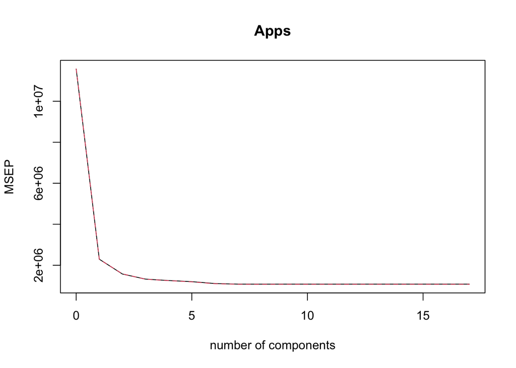

```r
validationplot(pls.fit, val.type = "MSEP")
```

CV error is minimised where we use 11 components. However, applying the one-standard-error rule, we should use 3 components:

```r
cv_errors <- RMSEP(pls.fit)$val[1,1,]
one_se_rule <- cv_errors[which.min(cv_errors)] + sd(cv_errors/sqrt(10))
names(which.max(cv_errors[cv_errors < one_se_rule]))
```

```
## [1] "3 comps"
```

Calculating test error for 3 components:

```r
pls.preds <- predict(pls.fit, newdata = College[-train_idx,], ncomp = 3)
sqrt(mean((College$Apps[-train_idx] - pls.preds)^2))
```

```
## [1] 1906.546
```

Calculating test error for 11 components:

```r
pls.preds <- predict(pls.fit, newdata = College[-train_idx,], ncomp = 11)
sqrt(mean((College$Apps[-train_idx] - pls.preds)^2))
```

```
## [1] 1325.4
```

**Comment on the results obtained. How accurately can we predict the number of college applications received? Is there much difference among the test errors resulting from these five approaches?**

Overall, lasso performed best of the models fitted, closely followed by the linear model. Ridge regression performed poorly, with much higher test error than lasso or the simple linear model. PLS and PCR both performed reasonably (slightly worse than the simple linear model) where the number of components was selected that minimised the test error. Where we use the one-standard-error rule to fit a model with fewer components, both performed very badly

Lasso RMSE was 1,316; this is almost half of the mean value of the `Apps` variable, so we do not appear able to predict this very accurately.

# Exercise 10

**We have seen that as the number of features used in a model increases, the training error will necessarily decrease, but the test error may not. We will now explore this in a simulated data set.**

**Generate a data set with $p=20$ features, $n= 1000$ observations, and an associated quantitative response vector generated according to the model**
$$Y=X\beta+\epsilon$$
**where $\beta$ has some elements that are exactly equal to zero.**

```r
set.seed(123)
n <- 1000
p <- 20

beta <- rep(1, 20)
# ensure at least some coefficients are zero
while(!0 %in% beta) {
  beta <- sample(0:5, 20, replace = TRUE)
}
# make input data
x <- matrix(
  rnorm(n * p),
  nrow = 1000,
  ncol = 20
)
# create response var
y <- (x %*% beta) + rnorm(n)
dataset <- data.frame(x, y)
```

**Split your data set into a training set containing 100 observations and a test set containing 900 observations.**

```r
train_idx <- sample(1:nrow(x), 100)
train <- dataset[train_idx,]
test <- dataset[-train_idx,]
```

**Perform best subset selection on the training set, and plot the training set MSE associated with the best model of each size.**

**Plot the test set MSE associated with the best model of each size.**

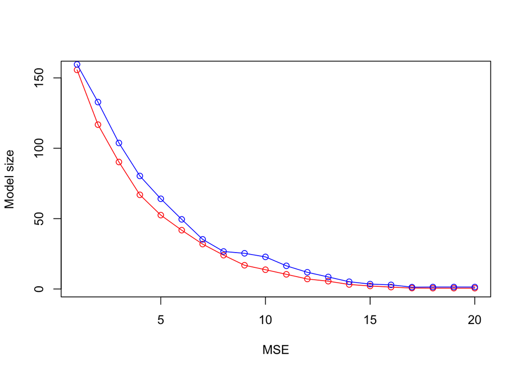

```r
reg.fit <- regsubsets(y ~ ., data = train, nvmax = 20)

predict.regsubsets <- function (object, newdata, id, ...){
  form <- as.formula(object$call[[2]])
  mat <- model.matrix(form,newdata)
  coefi <- coef(object ,id=id)
  xvars <- names(coefi)
  mat[,xvars] %*% coefi
}

# Training MSE
preds <- matrix(rep(NA, 100), nrow = 100, ncol = p)
for (i in 1:20) {
  preds[,i] <- predict(reg.fit, train, id = i)
}
train_mse <- apply(preds, 2, function(x) mean((train$y - x)^2))

# Test MSE
preds <- matrix(rep(NA, 900), nrow = 900, ncol = p)
for (i in 1:20) {
  preds[,i] <- predict(reg.fit, test, id = i)
}
test_mse <- apply(preds, 2, function(x) mean((test$y - x)^2))

# Plots
plot(1:20, train_mse, col = "red", type = "o", xlab = "MSE", ylab = "Model size")
points(1:20, test_mse, col = "blue", type = "o")
```

**For which model size does the test set MSE take on its minimum value? Comment on your results. If it takes on its minimum value for a model containing only an intercept or a model containing all of the features, then play around with the way that you are generating the data in (a) until you come up with a scenario in which the test set MSE is minimized for an intermediate model size.**

```r
# Which model minimises test_mse?
which.min(test_mse)
```

```
## [1] 17
```

```r
# Summarise reg.fit to get the terms in this model
summary(reg.fit)
```

```
## Subset selection object
## Call: regsubsets.formula(y ~ ., data = train, nvmax = 20)
## 20 Variables  (and intercept)
##     Forced in Forced out
## X1      FALSE      FALSE
## X2      FALSE      FALSE
## X3      FALSE      FALSE
## X4      FALSE      FALSE
## X5      FALSE      FALSE
## X6      FALSE      FALSE
## X7      FALSE      FALSE
## X8      FALSE      FALSE
## X9      FALSE      FALSE
## X10     FALSE      FALSE
## X11     FALSE      FALSE
## X12     FALSE      FALSE
## X13     FALSE      FALSE
## X14     FALSE      FALSE
## X15     FALSE      FALSE
## X16     FALSE      FALSE
## X17     FALSE      FALSE
## X18     FALSE      FALSE
## X19     FALSE      FALSE
## X20     FALSE      FALSE
## 1 subsets of each size up to 20
## Selection Algorithm: exhaustive
##           X1  X2  X3  X4  X5  X6  X7  X8  X9  X10 X11 X12 X13 X14 X15 X16 X17
## 1  ( 1 )  " " " " " " " " " " " " " " " " " " "*" " " " " " " " " " " " " " "
## 2  ( 1 )  " " " " " " " " " " " " " " " " " " "*" "*" " " " " " " " " " " " "
## 3  ( 1 )  " " " " " " " " " " "*" " " " " " " "*" "*" " " " " " " " " " " " "
## 4  ( 1 )  " " "*" " " " " " " "*" " " " " " " "*" "*" " " " " " " " " " " " "
## 5  ( 1 )  " " "*" " " " " " " "*" " " " " " " "*" "*" " " " " " " "*" " " " "
## 6  ( 1 )  " " "*" " " " " " " "*" " " " " " " "*" "*" " " " " " " "*" " " " "
## 7  ( 1 )  " " "*" " " " " " " "*" " " "*" " " "*" "*" " " " " " " "*" " " " "
## 8  ( 1 )  " " "*" " " " " " " "*" " " "*" "*" "*" "*" " " " " " " "*" " " " "
## 9  ( 1 )  " " "*" " " " " " " "*" " " "*" "*" "*" "*" " " " " " " "*" "*" " "
## 10  ( 1 ) "*" "*" " " " " " " "*" " " "*" "*" "*" "*" " " " " " " "*" "*" " "
## 11  ( 1 ) "*" "*" " " " " " " "*" " " "*" "*" "*" "*" " " " " "*" "*" "*" " "
## 12  ( 1 ) "*" "*" " " " " " " "*" "*" "*" "*" "*" "*" " " " " "*" "*" "*" " "
## 13  ( 1 ) "*" "*" " " " " " " "*" "*" "*" "*" "*" "*" " " " " "*" "*" "*" "*"
```

[output cut: 13 more lines]

```
## 6  ( 1 )  " " "*" " "
## 7  ( 1 )  " " "*" " "
## 8  ( 1 )  " " "*" " "
## 9  ( 1 )  " " "*" " "
## 10  ( 1 ) " " "*" " "
## 11  ( 1 ) " " "*" " "
## 12  ( 1 ) " " "*" " "
## 13  ( 1 ) " " "*" " "
## 14  ( 1 ) " " "*" " "
## 15  ( 1 ) " " "*" " "
## 16  ( 1 ) " " "*" " "
## 17  ( 1 ) " " "*" " "
## 18  ( 1 ) " " "*" "*"
## 19  ( 1 ) " " "*" "*"
## 20  ( 1 ) "*" "*" "*"
```

```r
# Which beta values are 0
which(beta == 0)
```

```
## [1] 12 18 20
```

Test MSE is minimised in the 17 variable model. This model omits terms for $X_{12}$, $X_{18}$ and $X_{20}$, which matches the values in $\beta$ which were zero. Furthermore, each subset appears to be nested in the previous one, suggesting that best subset has performed well on the simulated data set, successfully identifying the most relevant terms at each subset.

**How does the model at which the test set MSE is minimized compare to the true model used to generate the data? Comment on the coefficient values.**

```r
beta
```

```
##  [1] 2 5 2 1 1 5 2 4 3 5 5 0 1 2 4 2 2 0 3 0
```

```r
coef(reg.fit, id = 17)
```

```
## (Intercept)          X1          X2          X3          X4          X5
## -0.03251683  2.30744552  5.03967264  1.95094115  0.96869865  1.02441676
##          X6          X7          X8          X9         X10         X11
##  4.97694492  2.09355592  4.07755121  3.19922760  5.08826086  4.77361642
##         X13         X14         X15         X16         X17         X19
##  0.99431113  2.09628355  4.18085447  2.00595504  1.81682760  3.10657981
```

The other coefficients look reasonably close to the original values.

**Create a plot displaying $\sqrt{\sum_{j=1}^p(\beta_j−\hat{\beta}_j^r)^2}$ for a range of values of $r$, where $\hat{\beta}_j^r$ is the $j$<sup>th</sup> coefficient estimate for the best model containing $r$ coefficients. Comment on what you observe. How does this compare to the test MSE plot from (d)?**

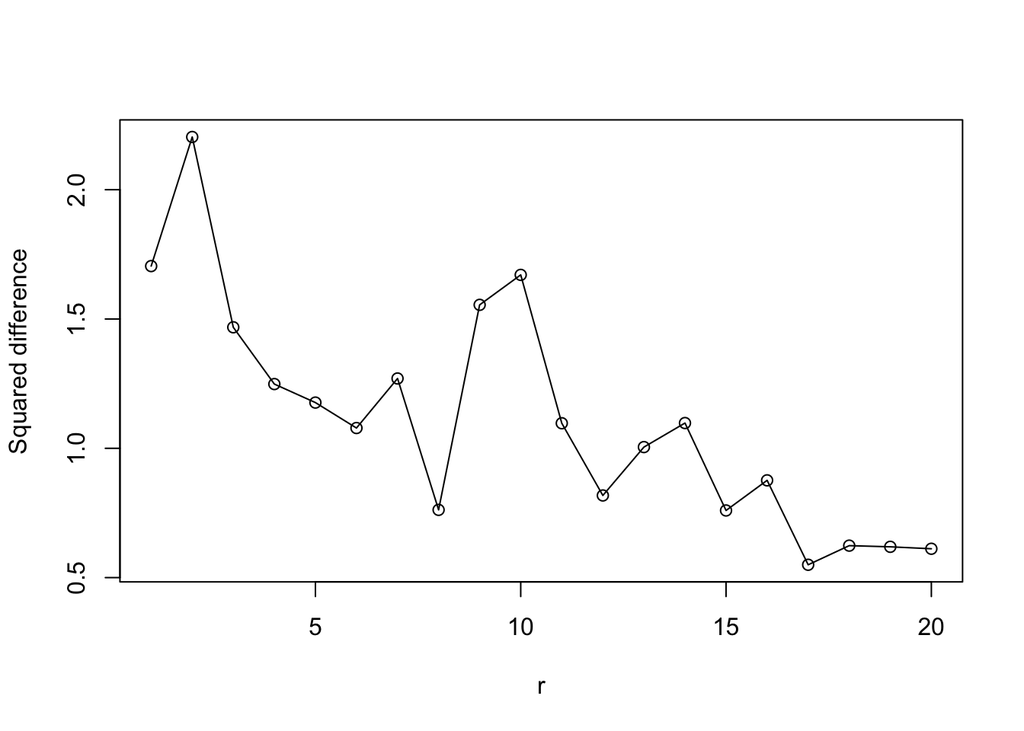

```r
squared_beta_diff <- function(r, object, beta) {
  coefi <- coef(object, id = r)
  idx <- as.numeric(sub("X", "", names(coefi))[-1])
  beta_r <- c(0, beta[idx])
  sqrt(sum((beta_r - coefi)^2))
}

plot(1:20, sapply(1:20, squared_beta_diff, reg.fit, beta), ylab = "Squared difference", xlab = "r", type = "o")
```

# Exercise 11

**We will now try to predict per capita crime rate in the `Boston` data set.**

**Try out some of the regression methods explored in this chapter, such as best subset selection, the lasso, ridge regression, and PCR. Present and discuss results for the approaches that you consider.**

We will use 10-fold cross validation to determine tuning parameters and the best number of predictors for best subset selection.

```r
set.seed(123)

# Train/test split
train_idx <- sample(seq_len(nrow(Boston)), 0.7 * nrow(Boston))
train <- Boston[train_idx,]
test <- Boston[-train_idx,]

# CV folds
k <- 10
k_folds <- sample(seq_len(k), nrow(train), replace = TRUE)
```

Best subsets selection:

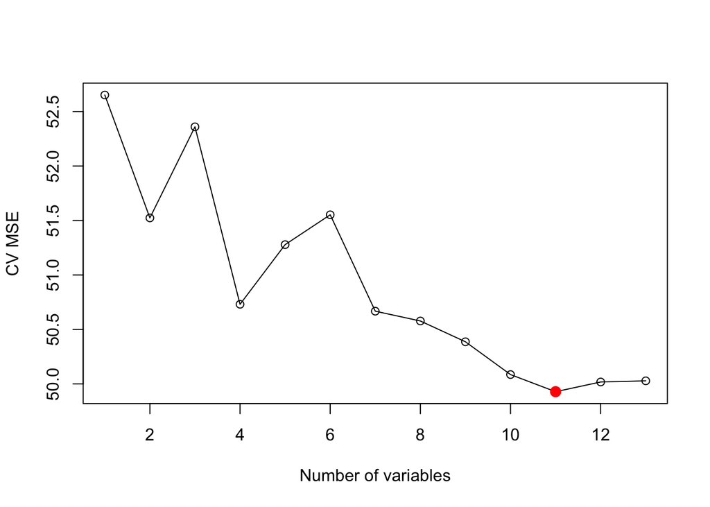

```r
# Best subset selecction
nvmax <- ncol(Boston) - 1

# CV to determine optimal number of predictors
cv_results <- matrix(NA, nrow = k, ncol = nvmax)
for (fold in seq_len(k)) {
  fit <- regsubsets(crim ~ ., data = train[k_folds != fold,], nvmax = nvmax)
  for (r in seq_len(nvmax)) {
    predictions <- predict.regsubsets(fit, train[k_folds == fold,], r)
    cv_results[fold, r] <- mean((predictions - train[k_folds == fold, "crim"])^2)
  }
}
cv_mses <- apply(cv_results, 2, mean)
plot(x = 1:nvmax, y = cv_mses, type = "o", xlab = "Number of variables", ylab = "CV MSE")
points(which.min(cv_mses), cv_mses[which.min(cv_mses)], col="red", cex=2, pch=20)
```

```r
# Cross validation suggests an 11 variable model for best subsets
best_subset_fit <- regsubsets(crim ~ ., data = train, nvmax = nvmax)
summary(best_subset_fit)
```

```
## Subset selection object
## Call: regsubsets.formula(crim ~ ., data = train, nvmax = nvmax)
## 13 Variables  (and intercept)
##         Forced in Forced out
## zn          FALSE      FALSE
## indus       FALSE      FALSE
## chas        FALSE      FALSE
## nox         FALSE      FALSE
## rm          FALSE      FALSE
## age         FALSE      FALSE
## dis         FALSE      FALSE
## rad         FALSE      FALSE
## tax         FALSE      FALSE
## ptratio     FALSE      FALSE
## black       FALSE      FALSE
## lstat       FALSE      FALSE
## medv        FALSE      FALSE
## 1 subsets of each size up to 13
## Selection Algorithm: exhaustive
##           zn  indus chas nox rm  age dis rad tax ptratio black lstat medv
## 1  ( 1 )  " " " "   " "  " " " " " " " " "*" " " " "     " "   " "   " "
## 2  ( 1 )  " " " "   " "  " " " " " " " " "*" " " " "     " "   "*"   " "
## 3  ( 1 )  " " " "   " "  " " " " " " " " "*" " " " "     "*"   " "   "*"
## 4  ( 1 )  "*" " "   " "  " " " " " " "*" "*" " " " "     " "   " "   "*"
## 5  ( 1 )  "*" " "   " "  " " " " " " "*" "*" " " " "     "*"   " "   "*"
## 6  ( 1 )  "*" "*"   " "  " " " " " " "*" "*" " " " "     "*"   " "   "*"
## 7  ( 1 )  "*" " "   " "  "*" " " " " "*" "*" " " "*"     "*"   " "   "*"
## 8  ( 1 )  "*" " "   " "  "*" " " " " "*" "*" "*" "*"     "*"   " "   "*"
## 9  ( 1 )  "*" "*"   " "  "*" " " " " "*" "*" " " "*"     "*"   "*"   "*"
## 10  ( 1 ) "*" " "   " "  "*" "*" " " "*" "*" "*" "*"     "*"   "*"   "*"
## 11  ( 1 ) "*" "*"   " "  "*" "*" " " "*" "*" "*" "*"     "*"   "*"   "*"
## 12  ( 1 ) "*" "*"   "*"  "*" "*" " " "*" "*" "*" "*"     "*"   "*"   "*"
## 13  ( 1 ) "*" "*"   "*"  "*" "*" "*" "*" "*" "*" "*"     "*"   "*"   "*"
```

10-fold cross validation suggested an 11 variable model using best subset selection. This model would omit the `chas` and `age` variables from the model.

Lasso regression:

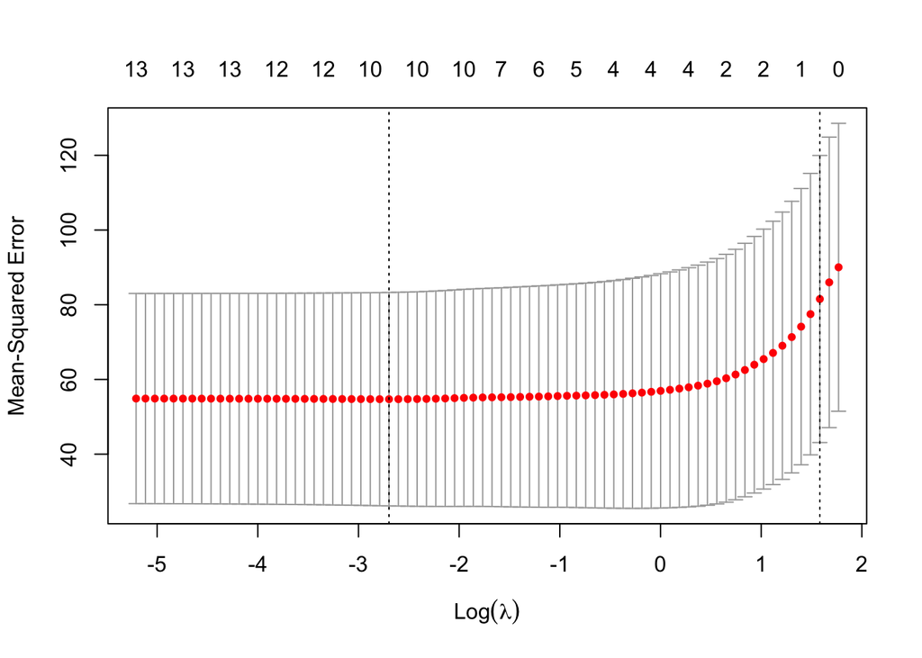

```r
# Set up model matrices
xtrain <- model.matrix(crim ~ ., data = train)[,-1]
xtest <- model.matrix(crim ~ ., data = test)[,-1]
# Fit model using CV to determine lambda
lasso.fit <- cv.glmnet(xtrain, train[, "crim"], alpha = 1)
# Plot
plot(lasso.fit)
```

```r
predict(lasso.fit, s = lasso.fit$lambda.min, type = "coefficients")
```

```
## 14 x 1 sparse Matrix of class "dgCMatrix"
##                        1
## (Intercept) 12.942651826
## zn           0.040136657
## indus       -0.070068882
## chas         .
## nox         -6.211557340
## rm           0.343857416
## age          .
## dis         -0.758014307
## rad          0.565833734
## tax          .
## ptratio     -0.219298173
## black       -0.007955042
## lstat        0.107824187
## medv        -0.199629722
```

10-fold cross-validation suggests a 10 variable model using lasso regression, with 3 coefficients shrunk to zero. The coefficients that are shrunk completely include both `chas` and `age`, which best subset selection omits from the best model (determined using 10-fold cross validation).

Ridge regression:

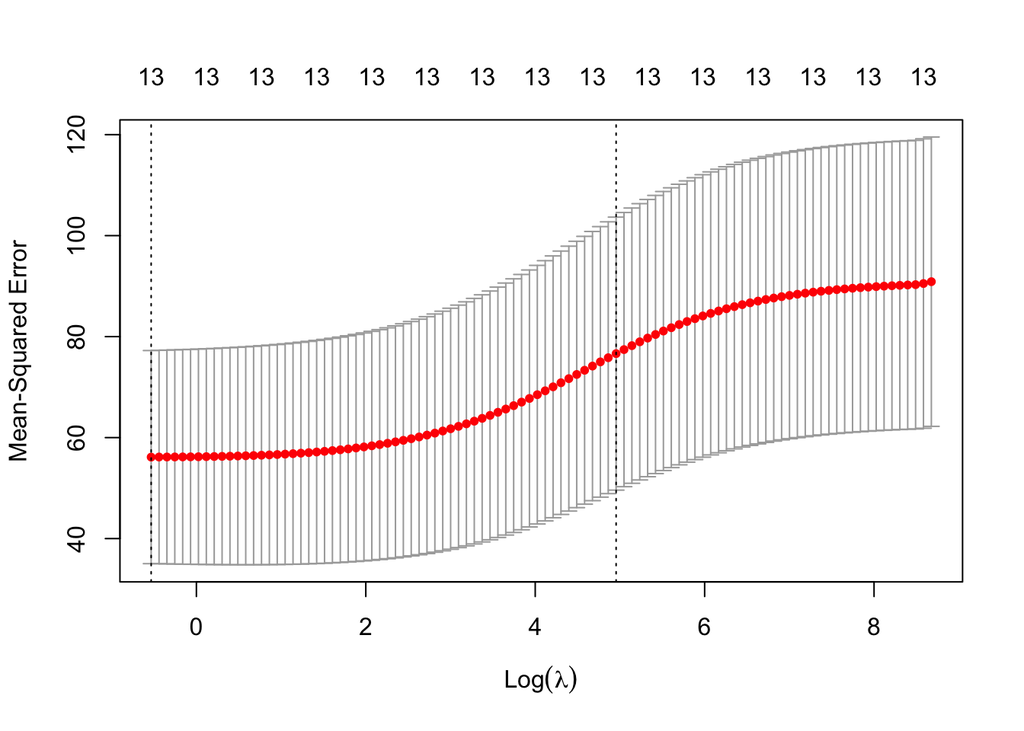

```r
# Fit model using CV to determine lambda
ridge.fit <- cv.glmnet(xtrain, train[, "crim"], alpha = 0)
# Plot
plot(ridge.fit)
```

```r
predict(ridge.fit, s = ridge.fit$lambda.min, type = "coefficients")
```

```
## 14 x 1 sparse Matrix of class "dgCMatrix"
##                        1
## (Intercept)  9.843861831
## zn           0.037648457
## indus       -0.085512482
## chas        -0.255107639
## nox         -5.186481136
## rm           0.473359162
## age          0.001306262
## dis         -0.717519067
## rad          0.472021888
## tax          0.003451528
## ptratio     -0.175899593
## black       -0.009139207
## lstat        0.134670493
## medv        -0.178552096
```

Ridge regression has resulted in comparatively small coefficients for both `tax` and `age` which were shrunk to zero by the lasso fit. In general, we can see that the coefficients are smaller than those for the linear model chosen by best subset selection.

```r
# Print coefficients from linear model for comparison
coef(lm(crim ~ ., data = train))
```

```
##   (Intercept)            zn         indus          chas           nox
##  18.438925576   0.051790800  -0.063530813  -0.169136713 -10.404698850
##            rm           age           dis           rad           tax
##   0.564083257   0.002443081  -1.006972202   0.657988601  -0.004600510
##       ptratio         black         lstat          medv
##  -0.322762548  -0.007877785   0.108371841  -0.248960593
```

Interestingly, `chas` has not been shrunk relative to the linear model coefficients.

PCR:

```r
# Fit PCR
pcr.fit <- pcr(crim ~ ., data = train, scale = TRUE, validation = "CV", segments = 10)
summary(pcr.fit)
```

```
## Data:    X dimension: 354 13
##  Y dimension: 354 1
## Fit method: svdpc
## Number of components considered: 13
##
## VALIDATION: RMSEP
## Cross-validated using 10 random segments.
##        (Intercept)  1 comps  2 comps  3 comps  4 comps  5 comps  6 comps
## CV           9.525    8.061    8.048    7.657    7.636    7.635    7.652
## adjCV        9.525    8.055    8.043    7.646    7.626    7.625    7.641
##        7 comps  8 comps  9 comps  10 comps  11 comps  12 comps  13 comps
## CV       7.637    7.638    7.518     7.543     7.554     7.499     7.418
## adjCV    7.624    7.628    7.503     7.528     7.540     7.481     7.401
##
## TRAINING: % variance explained
##       1 comps  2 comps  3 comps  4 comps  5 comps  6 comps  7 comps  8 comps
## X       48.58    61.36    70.50    77.35    83.36    88.23    91.30    93.45
## crim    29.82    30.41    37.81    38.42    38.54    38.72    39.17    40.09
##       9 comps  10 comps  11 comps  12 comps  13 comps
## X       95.54     97.16     98.50     99.54    100.00
## crim    41.44     41.62     41.62     43.09     44.25
```

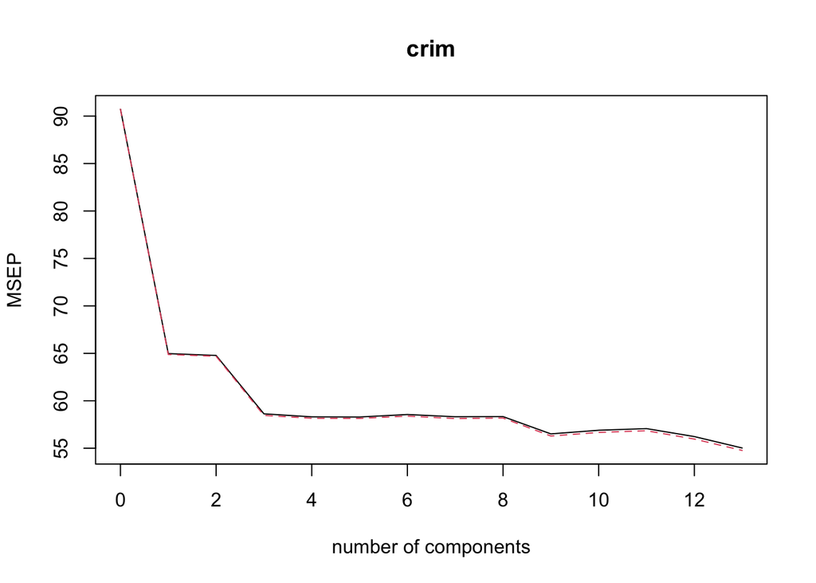

```r
# Plot MSEs
validationplot(pcr.fit, val.type = "MSEP")
```

```r
# Identify minimum
cv_errors <- RMSEP(pcr.fit)$val[1,1,]
names(which.min(cv_errors))
```

```
## [1] "13 comps"
```

Cross-validation error is minimised for PCR where the number of components is 13, which is the same as fitting the full linear model.

**Propose a model (or set of models) that seem to perform well on this data set, and justify your answer. Make sure that you are evaluating model performance using validation set error, cross-validation, or some other reasonable alternative, as opposed to using training error.**

Using the validation set approach to assess model performance:

```r
# Best subset:
preds <- predict.regsubsets(best_subset_fit, newdata = test, 11)
rmse_best_subset <- sqrt(mean((preds - test$crim)^2))

# Lasso:
preds <- predict(lasso.fit, xtest, s = lasso.fit$lambda.min)
rmse_lasso <- sqrt(mean((preds - test$crim)^2))

# Ridge:
preds <- predict(ridge.fit, xtest, s = ridge.fit$lambda.min)
rmse_ridge <- sqrt(mean((preds - test$crim)^2))

# PCR:
preds <- predict(pcr.fit, test, ncomp = 13)
rmse_pcr <- sqrt(mean((preds - test$crim)^2))

test_errors <- c(rmse_best_subset, rmse_lasso, rmse_ridge, rmse_pcr)
model_fits <- c("best_subset", "lasso", "ridge", "pcr")
for (i in 1:4) {
  print(paste0(model_fits[i], ": ", test_errors[i]))
}
```

```
## [1] "best_subset: 4.29949263179669"
## [1] "lasso: 4.2510616482043"
## [1] "ridge: 4.19206451944376"
## [1] "pcr: 4.29393755880996"
```

The best performing model is the ridge regression, with a root mean squared error of 4.19.

**Does your chosen model involve all of the features in the data set? Why or why not?**

The chosen model does contain all the features because ridge regression shrinks regression coefficients but unlike lasso, does not shrink them to zero. Hence, although a number of coefficients are smaller than in the unpenalised linear model, all features are still used in the ridge regression model.